# capstone project week 2

## Exploratory analysis

here we shall be exploring the data set in view of extracting insight of the qualities of our dataset that can be applied in developing a word predictive model. the predict model will be capable of generation likely next word given previous statement as reflected in swiftkey intelligent keyboard.this is achieved by the following steps 1. tokenizing the dataset into 2-gram and 3-gram words 2. selecting the most highest frequently occurring 2-grams and 3-grams word 3. visualising the most frequent word on the histograms

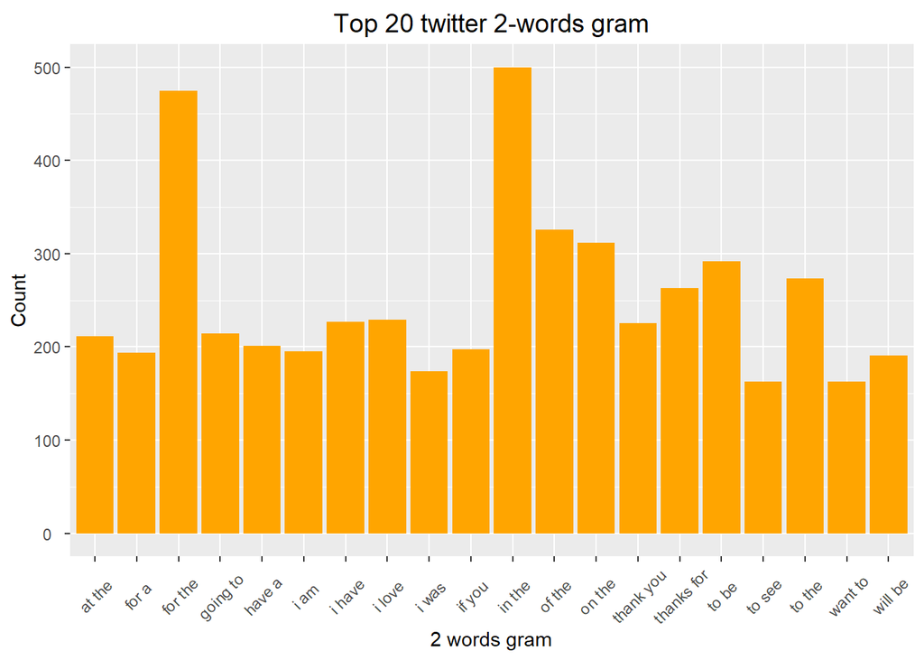

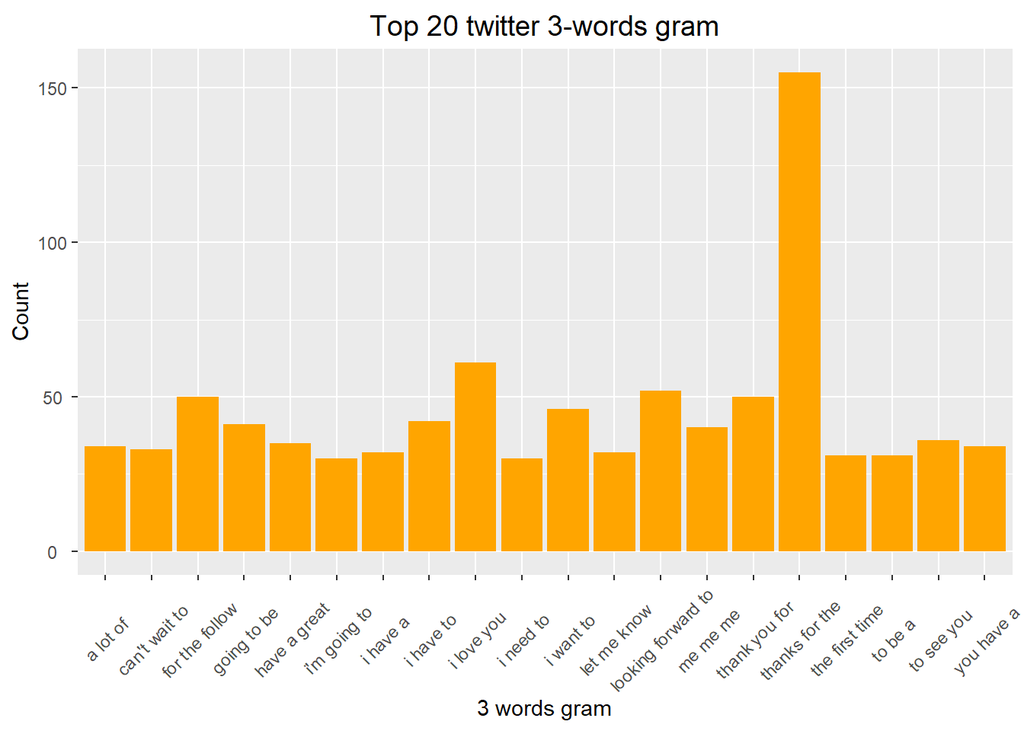

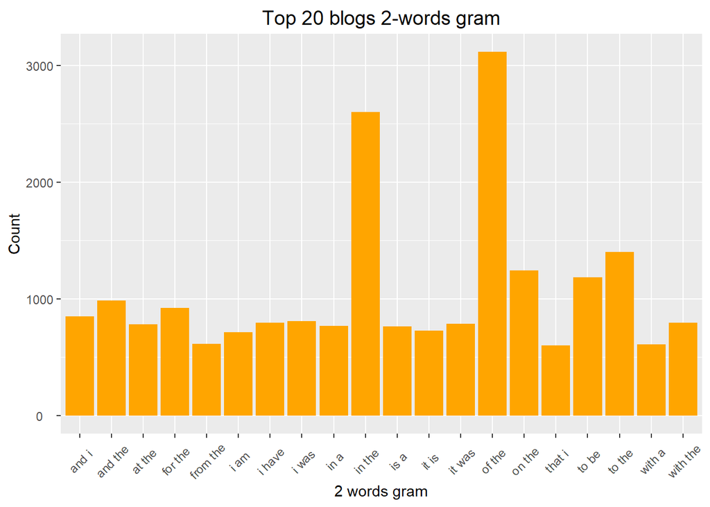

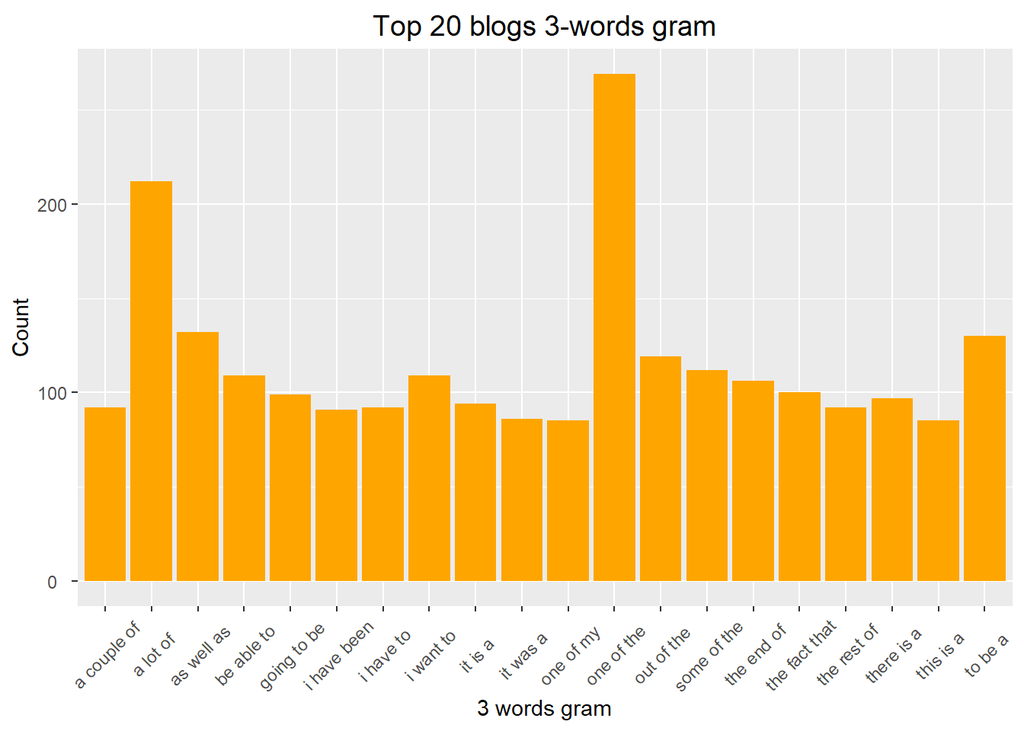

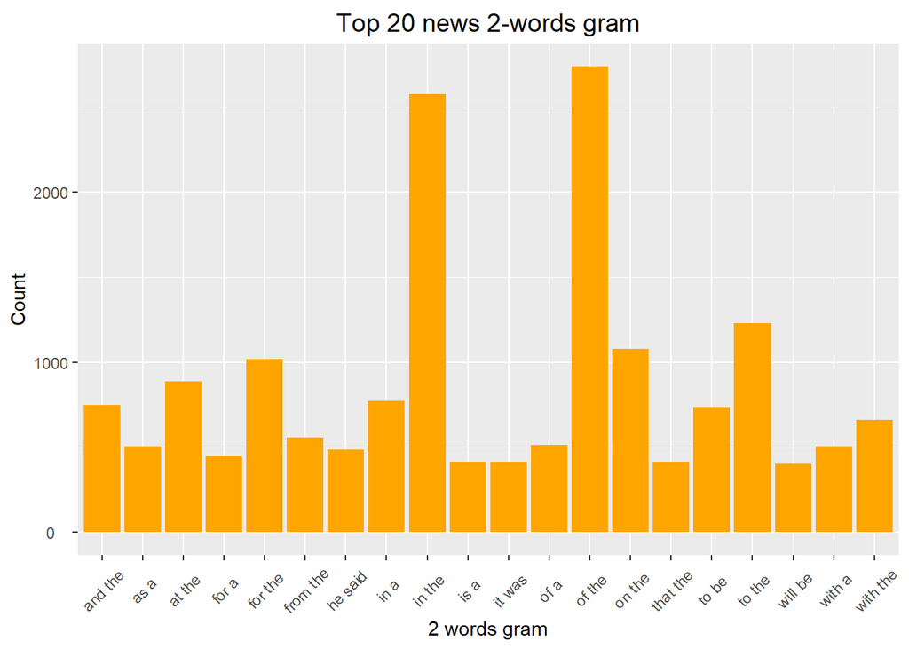

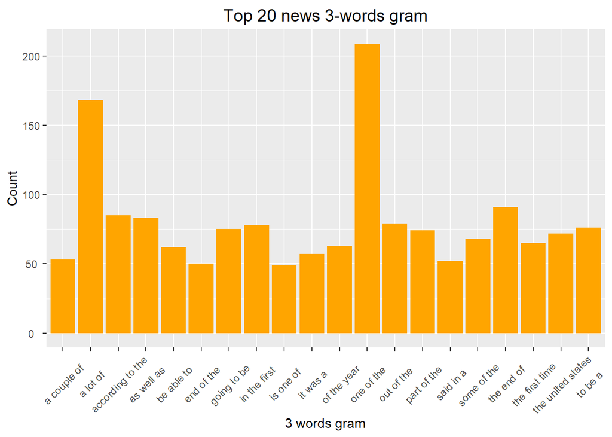